# Problem Set 2 Solution, Stats 506, F20

James Henderson, PhD

October 14, 2020

## About

This is an example solution to Problem Set 2 for Stats 506 in Fall 2020.

To build this document, run `Rscript -e "rmarkdown::render('./PS2_solution.Rmd')"` at the command line or `bash ps2_make.sh` to build this document *after* running the scripts which prepare the source data.

## Question 1

### Code Organization

- `0-ps1_q1_data.sh` uses the `wget` shell utility to download needed data.
- `1-ps1_q1_prep_data.R` cleans and creates minimal data files for analysis. This file creates `ps2_q1.RData` containing 4 tibbles:
  - `recs09` - cleaned/minimal 2009 data
  - `recs15` - cleaned/minimal 2015 data
  - `w09` - replicate weights for the 2009 data
  - `w15` - replicate weights for the 2015 data.
- `2-ps2_q1_analysis.R` - defines a function that can be used to estimate either means for numeric or logical variables, and proportions for unique levels in factor or character variables. That function is then used to produce the needed estimates, which are then combined to compute differences.
- `PS2_Solution.Rmd` runs `2-ps2_q1_analysis.R` and builds the page you are reading. Code for figures and tables can be found here.
- `3-ps2_make.sh` runs the first two data preparation scripts and then builds this document.

### Solution

```r
source('./2-ps2_q1_analysis.R')
```

#### Number of TVs

The figures and table below compare the average number of televisions per household in 2009 and 2015 by Census Division and rurality.

##### Figures

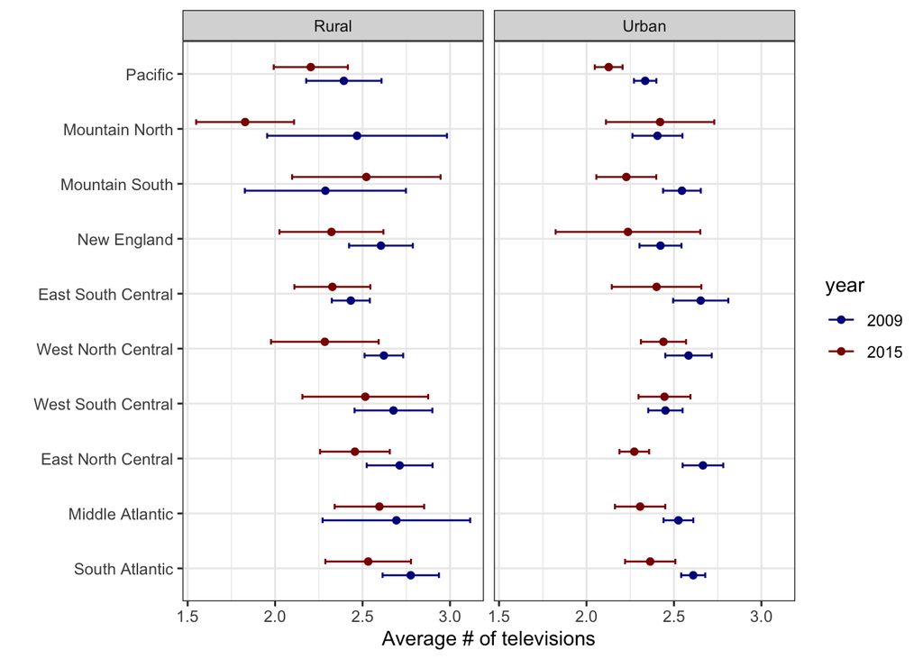

**Figure 1a.** *Average number of televisions per household.* Estimates use the 2009 and 2015 RECS data.

```r
cap1a = paste(
  "**Figure 1a.** *Average number of televisions per household.* Estimates use",
  "the 2009 and 2015 RECS data."
)

div_order = {
  tv_n %>%
   group_by(division) %>%
   summarize( tv_n = mean(tv_n), .groups = 'drop' ) %>%
   arrange(desc(tv_n))
}[['division']]

tv_n %>%
  mutate(
    division = factor(division, div_order),
    `Urban Type` = rurality
  ) %>%
  ggplot(
    aes(x = division, y = tv_n, color = year)) +
  geom_point( position = position_dodge(.5) ) +
  geom_errorbar(
    aes(ymin = tv_n_lwr, ymax = tv_n_upr),
    position = position_dodge(.5), width = 0.2
  ) +
  facet_wrap(~`Urban Type`) +
  coord_flip() +
  theme_bw() +
  scale_color_manual(values = c('darkblue', 'darkred')) +
  ylab('Average # of televisions') +
  xlab('')
```

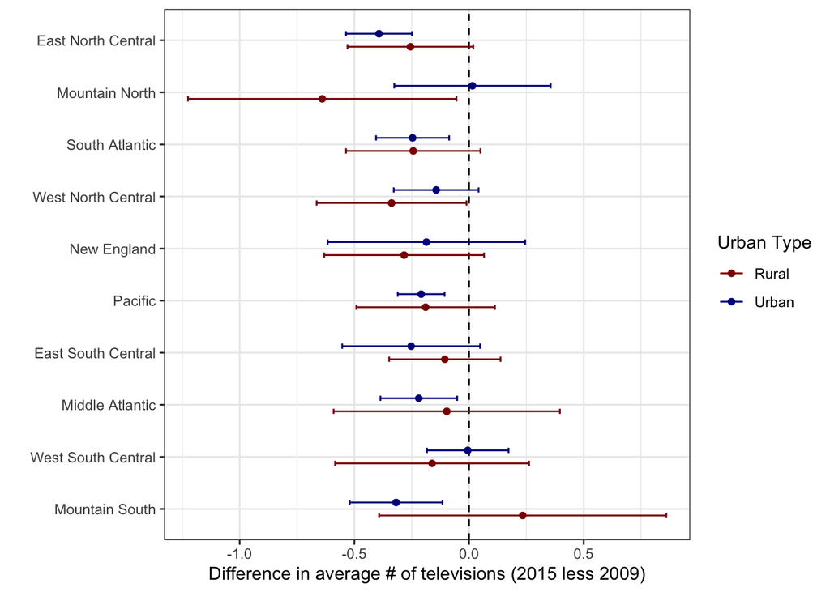

**Figure 1b.** *Difference in average number of televisions per household 2015 less 2009.*

```r
cap1b = paste(
  "**Figure 1b.** *Difference in average number of televisions per household",
  "2015 less 2009.*"
)

div_order = {
  tv_n_diff %>%
   group_by(division) %>%
   summarize( diff = mean(diff), .groups = 'drop' ) %>%
   arrange(desc(diff))
}[['division']]

tv_n_diff %>%
  mutate(
    division = factor(division, div_order),
    `Urban Type` = rurality
  ) %>%
  ggplot( aes(x = division, y = diff, color = `Urban Type`) ) +
  geom_hline(yintercept = 0, lty = 'dashed') +
  geom_point( position = position_dodge(.5) ) +
  geom_errorbar(
    aes(ymin = lwr, ymax = upr),
    position = position_dodge(.5), width = 0.2
  ) +
  coord_flip() +
  theme_bw() +
  scale_color_manual(values = c('darkred', 'darkblue')) +
  ylab('Difference in average # of televisions (2015 less 2009)') +
  xlab('')
```

##### Table

```r
cap_tab1 = paste(
 "**Table 1.** *Average number of televisions per household 2009 and 2015.*",
 "Numbers in parantheses represent 95% confidence intervals."
)

tab1 = tv_n %>%
  mutate(
    pretty = sprintf('<div>%4.2f</div> <div>(%4.2f, %4.2f)</div>',
                     tv_n, tv_n_lwr, tv_n_upr)
  ) %>%
  pivot_wider(
    id_cols = c('division', 'rurality'),
    names_from = 'year',
    values_from = 'pretty'
  )

tab1 = tab1 %>%
  left_join(
    transmute(tv_n_diff,
           division,
           rurality,
           Change =  sprintf('<div>%4.2f</div> <div>(%4.2f, %4.2f)</div>',
                             diff, lwr, upr)
    ),
    by = c('division', 'rurality')
)

tab1 %>%
  select(
    `Census Division` = division,
    `Urban Type` = rurality,
    `2009`,
    `2015`,
    Change
  ) %>%
  knitr::kable(
    format = 'html',
    escape = FALSE,
    align = 'llccc',
    cap = cap_tab1
  ) %>%
  kableExtra::kable_styling("striped", full_width = TRUE)
```

**Table 1.** *Average number of televisions per household 2009 and 2015.* Numbers in parantheses represent 95% confidence intervals.

| Census Division | Urban Type | 2009 | 2015 | Change |
| --- | --- | --- | --- | --- |
| New England | Rural | 2.61 (2.42, 2.79) | 2.32 (2.02, 2.62) | -0.28 (-0.63, 0.07) |
| New England | Urban | 2.42 (2.30, 2.54) | 2.24 (1.82, 2.65) | -0.19 (-0.62, 0.24) |
| Middle Atlantic | Rural | 2.69 (2.27, 3.12) | 2.60 (2.34, 2.85) | -0.10 (-0.59, 0.40) |
| Middle Atlantic | Urban | 2.53 (2.44, 2.61) | 2.31 (2.16, 2.45) | -0.22 (-0.39, -0.05) |
| East North Central | Rural | 2.71 (2.52, 2.90) | 2.46 (2.26, 2.66) | -0.26 (-0.53, 0.02) |
| East North Central | Urban | 2.67 (2.55, 2.78) | 2.27 (2.19, 2.36) | -0.39 (-0.54, -0.25) |
| West North Central | Rural | 2.62 (2.51, 2.73) | 2.28 (1.98, 2.59) | -0.34 (-0.66, -0.01) |
| West North Central | Urban | 2.58 (2.45, 2.72) | 2.44 (2.31, 2.57) | -0.14 (-0.33, 0.04) |
| South Atlantic | Rural | 2.78 (2.61, 2.94) | 2.53 (2.29, 2.78) | -0.24 (-0.54, 0.05) |
| South Atlantic | Urban | 2.61 (2.54, 2.68) | 2.36 (2.22, 2.51) | -0.25 (-0.41, -0.09) |
| East South Central | Rural | 2.43 (2.32, 2.54) | 2.33 (2.11, 2.54) | -0.11 (-0.35, 0.14) |
| East South Central | Urban | 2.65 (2.50, 2.81) | 2.40 (2.14, 2.66) | -0.25 (-0.55, 0.05) |
| West South Central | Rural | 2.68 (2.45, 2.90) | 2.52 (2.16, 2.88) | -0.16 (-0.58, 0.26) |
| West South Central | Urban | 2.45 (2.35, 2.55) | 2.45 (2.30, 2.59) | -0.01 (-0.18, 0.17) |
| Mountain North | Rural | 2.47 (1.95, 2.98) | 1.83 (1.55, 2.11) | -0.64 (-1.23, -0.05) |
| Mountain North | Urban | 2.41 (2.26, 2.55) | 2.42 (2.11, 2.73) | 0.02 (-0.33, 0.36) |
| Mountain South | Rural | 2.29 (1.83, 2.75) | 2.52 (2.10, 2.95) | 0.23 (-0.39, 0.86) |
| Mountain South | Urban | 2.55 (2.44, 2.65) | 2.23 (2.06, 2.40) | -0.32 (-0.52, -0.12) |
| Pacific | Rural | 2.39 (2.18, 2.61) | 2.20 (1.99, 2.42) | -0.19 (-0.49, 0.11) |
| Pacific | Urban | 2.34 (2.27, 2.40) | 2.13 (2.05, 2.21) | -0.21 (-0.31, -0.11) |

#### Type of Primary Television

##### Figures

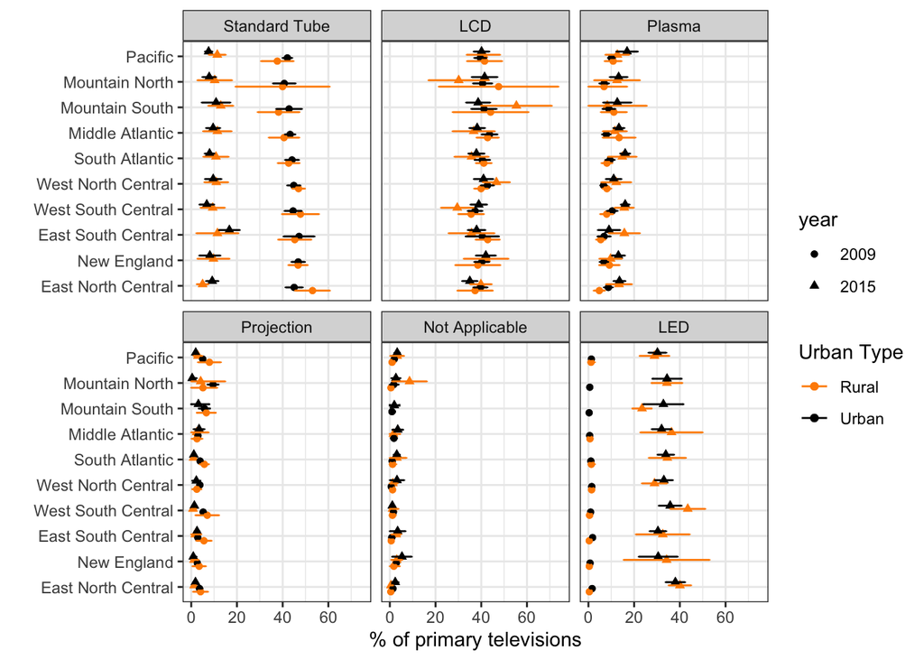

**Figure 2a.** *Primary television type.* This figure shows the percent of homes with each television type for their most used television. Note the increase in the percent of homes with LED TV's and the corresponding decrease in standard tube televisions.

```r
cap2a = paste(
  "**Figure 2a.** *Primary television type.* This figure shows the percent of",
  "homes with each television type for their most used television. Note the",
  "increase in the percent of homes with LED TV's and the corresponding",
  "decrease in standard tube televisions."
)
## order divisions
div_order = {
  tv_type %>%
   filter(tv_type == 'Standard Tube' & year == 2009) %>%
   group_by(division) %>%
   summarize( p_tube = mean(p), .groups = 'drop' ) %>%
   arrange(desc(p_tube))
}[['division']]

## order tv_type
type_order = {
  tv_type %>%
   filter(year == 2009) %>%
   group_by(tv_type) %>%
   summarize( p = mean(p), .groups = 'drop' ) %>%
   arrange(desc(p))
}[['tv_type']]

## construct a plot
tv_type %>%
  mutate(
    division = factor(division, div_order),
    `Urban Type` = rurality,
    tv_type = factor(tv_type, type_order)
  ) %>%
  ggplot( aes(x = division, y = p, shape = year, color = `Urban Type`) ) +
  geom_point( position = position_dodge(.5) ) +
  geom_point( position = position_dodge(.5) ) +
  geom_errorbar(
    aes(ymin = p_lwr, ymax = p_upr),
    position = position_dodge(.5), width = 0.2
  ) +
  facet_wrap(~ tv_type) +
  coord_flip() +
  theme_bw() +
  scale_color_manual( values = c('darkorange', 'black') ) +
  ylab('% of primary televisions') +
  xlab('') +
  ylim(c(0, 75))
```

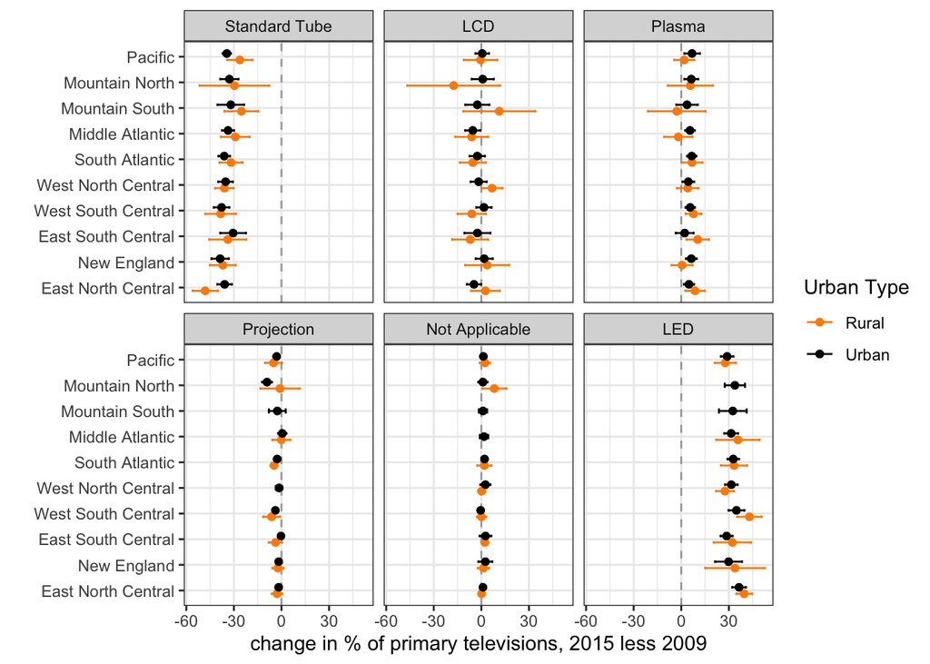

**Figure 2b.** *Changes in primary television type, 2015 less 2009.*

```r
cap2b = paste(
  "**Figure 2b.** *Changes in primary television type, 2015 less 2009.*"
)

tv_type_diff %>%
  mutate(
    division = factor(division, div_order),
    `Urban Type` = rurality,
    tv_type = factor(tv_type, type_order)
  ) %>%
  ggplot( aes(x = division, y = d, color = `Urban Type`) ) +
  geom_hline( yintercept = 0, lty = 'dashed', color = 'darkgrey' )  +
  geom_point( position = position_dodge(.5) ) +
  geom_point( position = position_dodge(.5) ) +
  geom_errorbar(
    aes(ymin = d_lwr, ymax = d_upr),
    position = position_dodge(.5), width = 0.2
  ) +
  facet_wrap(~ tv_type) +
  coord_flip() +
  theme_bw() +
  scale_color_manual( values = c('darkorange', 'black') ) +
  ylab('change in % of primary televisions, 2015 less 2009') +
  xlab('')
```

##### Table

```r
cap_tab2 = paste(
 "**Table 2.** *Primary TV types in US households (%) in 2009 and 2015.*",
 "Numbers in parantheses are 95% confidence intervals."
)

tv_type = tv_type %>%
  mutate(
    pretty = sprintf('%4.1f<br>(%4.1f, %4.1f)',
                     p, p_lwr, p_upr),
    tv_type = factor(tv_type, rev(type_order))
  )

## 2009/2015 by rurality
tab2_urb = tv_type %>%
  filter(rurality == 'Urban') %>%
  pivot_wider(
    id_cols = c('division', 'tv_type'),
    names_from = 'year',
    names_prefix = 'urban_',
    values_from = 'pretty',
    values_fill = '--'
  )
tab2_rul = tv_type %>%
  filter(rurality == 'Rural') %>%
  pivot_wider(
    id_cols = c('division', 'tv_type'),
    names_from = 'year',
    names_prefix =  'rural_',
    values_from = 'pretty',
    values_fill = '--'
  )
tab2 = left_join(tab2_urb, tab2_rul, by = c('division', 'tv_type'))

## changes
tab2_diff = tv_type_diff %>%
    transmute(
      division,
      rurality,
      tv_type = factor(tv_type, rev(type_order)),
      Change =  sprintf('%4.1f<br>(%4.1f, %4.1f)',
                        d, d_lwr, d_upr)
    ) %>%
  pivot_wider(
    id_cols = c('division', 'tv_type'),
    names_from = 'rurality',
    values_from = 'Change',
    values_fill = '--'
  )
tab2 = left_join(tab2, tab2_diff, by = c('division', 'tv_type') )

cn = c('Census Division', 'TV Type',
       '2009', '2015', 'Change',
       '2009', '2015', 'Change'
       )
tab2 %>%
  select(
    division,
    tv_type,
    urban_2009,
    urban_2015,
    Urban,
    rural_2009,
    rural_2015,
    Rural
  ) %>%
  arrange(division, desc(tv_type)) %>%
  knitr::kable(
    format = 'html',
    escape = FALSE,
    align = 'llcccccc',
    col.names = cn,
    cap = cap_tab2
  ) %>%
  kableExtra::kable_styling("striped", full_width = TRUE) %>%
  kableExtra::add_header_above(header = c(' ' = 2, 'Urban' = 3, 'Rural' = 3))
```

**Table 2.** *Primary TV types in US households (%) in 2009 and 2015.* Numbers in parantheses are 95% confidence intervals.

| Census Division | TV Type | Urban 2009 | Urban 2015 | Urban Change | Rural 2009 | Rural 2015 | Rural Change |
| --- | --- | --- | --- | --- | --- | --- | --- |
| New England | Standard Tube | 46.8 (43.9, 49.7) | 8.1 ( 3.5, 12.7) | -38.7 (-44.1, -33.2) | 46.7 (42.5, 50.9) | 9.7 ( 2.7, 16.7) | -37.0 (-45.2, -28.9) |
| New England | LCD | 40.2 (37.0, 43.4) | 42.0 (37.7, 46.3) | 1.8 (-3.6, 7.2) | 38.5 (28.7, 48.3) | 42.1 (32.4, 51.8) | 3.6 (-10.2, 17.5) |
| New England | Plasma | 6.8 ( 5.0, 8.6) | 13.1 (10.3, 16.0) | 6.3 ( 2.9, 9.7) | 9.2 ( 4.7, 13.6) | 9.7 ( 4.8, 14.6) | 0.5 (-6.1, 7.1) |
| New England | Projection | 2.7 ( 1.8, 3.5) | 0.9 ( 0.0, 2.3) | -1.8 (-3.4, -0.1) | 3.5 ( 0.5, 6.4) | 1.2 ( 0.0, 3.2) | -2.2 (-5.8, 1.3) |
| New England | Not Applicable | 2.8 ( 1.8, 3.8) | 5.3 ( 1.0, 9.6) | 2.5 (-1.9, 6.9) | 1.7 ( 0.0, 4.3) | 3.0 ( 0.6, 5.4) | 1.3 (-2.3, 4.8) |
| New England | LED | 0.7 ( 0.3, 1.2) | 30.5 (22.0, 39.0) | 29.8 (21.3, 38.3) | 0.4 ( 0.0, 1.1) | 34.2 (15.4, 53.0) | 33.8 (15.1, 52.6) |
| Middle Atlantic | Standard Tube | 43.3 (41.0, 45.5) | 9.6 ( 6.5, 12.6) | -33.7 (-37.5, -29.9) | 40.6 (33.9, 47.3) | 11.4 ( 5.2, 17.6) | -29.2 (-38.3, -20.1) |
| Middle Atlantic | LCD | 43.6 (40.2, 47.0) | 38.2 (34.8, 41.6) | -5.4 (-10.2, -0.6) | 42.8 (38.0, 47.6) | 36.7 (27.5, 45.9) | -6.1 (-16.5, 4.3) |
| Middle Atlantic | Plasma | 7.8 ( 6.0, 9.7) | 13.3 (10.9, 15.7) | 5.5 ( 2.4, 8.5) | 13.4 ( 6.3, 20.6) | 11.5 ( 6.3, 16.8) | -1.9 (-10.7, 7.0) |
| Middle Atlantic | Projection | 2.9 ( 1.8, 4.1) | 3.4 ( 1.0, 5.8) | 0.5 (-2.2, 3.1) | 2.5 ( 0.2, 4.8) | 2.4 ( 0.0, 7.6) | -0.1 (-5.8, 5.6) |
| Middle Atlantic | Not Applicable | 1.8 ( 0.5, 3.1) | 3.5 ( 1.2, 5.8) | 1.7 (-1.0, 4.3) | -- | 1.6 ( 0.0, 4.5) | -- |
| Middle Atlantic | LED | 0.5 ( 0.1, 1.0) | 32.0 (27.7, 36.3) | 31.5 (27.1, 35.8) | 0.7 ( 0.0, 1.8) | 36.4 (22.7, 50.0) | 35.7 (22.0, 49.3) |
| East North Central | Standard Tube | 45.0 (41.3, 48.8) | 9.2 ( 6.5, 11.9) | -35.8 (-40.5, -31.2) | 53.1 (45.5, 60.7) | 5.0 ( 2.4, 7.5) | -48.1 (-56.1, -40.1) |
| East North Central | LCD | 39.6 (36.6, 42.7) | 35.0 (31.7, 38.3) | -4.6 (-9.2, -0.1) | 37.3 (29.6, 45.0) | 39.8 (35.1, 44.6) | 2.5 (-6.5, 11.6) |
| East North Central | Plasma | 8.7 ( 6.8, 10.6) | 13.6 (11.0, 16.2) | 4.9 ( 1.6, 8.1) | 4.8 ( 2.3, 7.2) | 13.4 ( 7.8, 19.0) | 8.6 ( 2.5, 14.8) |
| East North Central | Projection | 3.6 ( 2.4, 4.9) | 1.9 ( 0.9, 2.8) | -1.8 (-3.4, -0.2) | 4.1 ( 0.8, 7.3) | 1.3 ( 0.5, 2.1) | -2.8 (-6.1, 0.6) |
| East North Central | Not Applicable | 1.4 ( 0.4, 2.3) | 2.4 ( 0.9, 3.8) | 1.0 (-0.7, 2.8) | 0.4 ( 0.0, 1.2) | 0.5 ( 0.0, 1.4) | 0.1 (-1.2, 1.3) |
| East North Central | LED | 1.6 ( 0.6, 2.6) | 38.0 (33.8, 42.3) | 36.4 (32.1, 40.8) | 0.4 ( 0.0, 1.2) | 40.0 (35.1, 44.9) | 39.6 (34.7, 44.6) |
| West North Central | Standard Tube | 44.9 (42.0, 47.7) | 9.6 ( 6.0, 13.2) | -35.3 (-39.9, -30.7) | 47.0 (44.2, 49.8) | 11.0 ( 5.8, 16.1) | -36.0 (-41.9, -30.1) |
| West North Central | LCD | 42.7 (39.9, 45.5) | 41.0 (36.8, 45.2) | -1.7 (-6.8, 3.4) | 39.9 (36.9, 42.9) | 46.6 (40.7, 52.5) | 6.7 ( 0.1, 13.3) |
| West North Central | Plasma | 6.6 ( 5.2, 8.0) | 11.0 ( 7.6, 14.5) | 4.4 ( 0.8, 8.1) | 8.1 ( 6.2, 10.0) | 12.2 ( 5.7, 18.7) | 4.1 (-2.7, 10.9) |
| West North Central | Projection | 3.8 ( 2.7, 4.9) | 2.2 ( 0.5, 3.9) | -1.6 (-3.6, 0.5) | 2.4 ( 0.5, 4.4) | -- | -- |
| West North Central | Not Applicable | 0.6 ( 0.2, 1.0) | 3.1 ( 0.0, 6.3) | 2.5 (-0.7, 5.7) | 1.2 ( 0.3, 2.1) | 1.3 ( 0.0, 3.4) | 0.1 (-2.1, 2.4) |
| West North Central | LED | 1.4 ( 1.0, 1.9) | 33.0 (29.1, 36.9) | 31.6 (27.6, 35.5) | 1.4 ( 0.4, 2.3) | 28.9 (23.4, 34.4) | 27.5 (22.0, 33.1) |
| South Atlantic | Standard Tube | 44.1 (41.1, 47.1) | 8.0 ( 5.9, 10.1) | -36.1 (-39.8, -32.4) | 42.6 (37.9, 47.4) | 10.8 ( 5.3, 16.3) | -31.8 (-39.1, -24.5) |
| South Atlantic | LCD | 40.5 (37.1, 43.8) | 37.9 (34.4, 41.4) | -2.6 (-7.4, 2.2) | 41.1 (37.7, 44.5) | 35.7 (28.3, 43.2) | -5.4 (-13.6, 2.8) |
| South Atlantic | Plasma | 9.4 ( 7.4, 11.5) | 16.1 (13.9, 18.2) | 6.6 ( 3.7, 9.6) | 8.1 ( 5.7, 10.4) | 14.8 ( 8.6, 21.0) | 6.7 ( 0.1, 13.4) |
| South Atlantic | Projection | 3.9 ( 2.7, 5.0) | 1.1 ( 0.7, 1.6) | -2.7 (-4.0, -1.5) | 5.7 ( 3.7, 7.7) | 1.0 ( 0.1, 2.0) | -4.7 (-7.0, -2.5) |
| South Atlantic | Not Applicable | 1.0 ( 0.5, 1.6) | 3.0 ( 1.7, 4.4) | 2.0 ( 0.6, 3.4) | 1.2 ( 0.0, 2.8) | 3.1 ( 0.0, 7.2) | 1.9 (-2.6, 6.4) |
| South Atlantic | LED | 1.1 ( 0.5, 1.7) | 33.9 (30.2, 37.5) | 32.8 (29.1, 36.4) | 1.3 ( 0.0, 2.8) | 34.5 (26.4, 42.6) | 33.3 (25.0, 41.5) |
| East South Central | Standard Tube | 47.2 (40.4, 53.9) | 16.7 (12.1, 21.2) | -30.5 (-38.6, -22.4) | 45.3 (38.1, 52.5) | 11.5 ( 2.3, 20.6) | -33.8 (-45.5, -22.2) |
| East South Central | LCD | 40.5 (33.2, 47.7) | 38.0 (34.2, 41.8) | -2.5 (-10.7, 5.7) | 42.8 (37.5, 48.1) | 35.7 (25.7, 45.7) | -7.1 (-18.4, 4.2) |
| East South Central | Plasma | 6.8 ( 4.0, 9.7) | 9.0 ( 4.2, 13.8) | 2.2 (-3.5, 7.8) | 5.4 ( 3.4, 7.4) | 15.7 ( 8.9, 22.5) | 10.3 ( 3.3, 17.4) |
| East South Central | Projection | 2.9 ( 1.8, 3.9) | 2.5 ( 1.5, 3.6) | -0.3 (-1.8, 1.1) | 5.6 ( 2.2, 8.9) | 1.8 ( 0.0, 4.4) | -3.8 (-8.0, 0.5) |
| East South Central | Not Applicable | 0.8 ( 0.0, 2.1) | 3.4 ( 0.0, 6.9) | 2.6 (-1.1, 6.3) | 0.6 ( 0.0, 1.5) | 2.8 ( 0.7, 4.9) | 2.2 (-0.1, 4.5) |
| East South Central | LED | 1.8 ( 0.8, 2.9) | 30.4 (26.8, 34.0) | 28.6 (24.8, 32.4) | 0.3 ( 0.0, 1.1) | 32.5 (20.8, 44.3) | 32.2 (20.4, 44.0) |
| West South Central | Standard Tube | 44.6 (40.8, 48.3) | 6.8 ( 3.6, 10.0) | -37.8 (-42.7, -32.9) | 47.8 (39.7, 55.9) | 9.4 ( 4.1, 14.7) | -38.4 (-48.1, -28.7) |
| West South Central | LCD | 37.3 (34.1, 40.4) | 38.9 (35.3, 42.5) | 1.6 (-3.2, 6.4) | 35.6 (30.0, 41.2) | 29.5 (22.4, 36.6) | -6.1 (-15.1, 2.9) |
| West South Central | Plasma | 10.4 ( 8.1, 12.7) | 16.1 (14.2, 18.0) | 5.6 ( 2.7, 8.6) | 8.0 ( 5.2, 10.8) | 15.7 (11.5, 19.8) | 7.7 ( 2.7, 12.7) |
| West South Central | Projection | 5.2 ( 4.0, 6.4) | 1.4 ( 0.5, 2.3) | -3.8 (-5.4, -2.3) | 7.0 ( 1.9, 12.1) | 0.7 ( 0.0, 2.1) | -6.3 (-11.6, -0.9) |
| West South Central | Not Applicable | 1.5 ( 0.6, 2.5) | 1.1 ( 0.2, 2.0) | -0.5 (-1.8, 0.8) | 1.2 ( 0.0, 2.6) | 1.2 ( 0.0, 3.7) | 0.1 (-2.8, 3.0) |
| West South Central | LED | 1.0 ( 0.4, 1.5) | 35.8 (30.8, 40.7) | 34.8 (29.8, 39.8) | 0.5 ( 0.0, 1.5) | 43.5 (35.8, 51.1) | 43.0 (35.3, 50.7) |
| Mountain North | Standard Tube | 40.7 (35.8, 45.7) | 7.9 ( 4.9, 10.8) | -32.8 (-38.6, -27.1) | 40.0 (19.4, 60.5) | 10.3 ( 2.7, 17.8) | -29.7 (-51.6, -7.8) |
| Mountain North | LCD | 40.6 (36.4, 44.8) | 41.5 (35.9, 47.1) | 0.9 (-6.1, 7.9) | 47.6 (21.5, 73.7) | 30.1 (16.9, 43.3) | -17.5 (-46.7, 11.8) |
| Mountain North | Plasma | 6.9 ( 4.8, 9.0) | 13.2 ( 9.4, 17.1) | 6.3 ( 1.9, 10.7) | 6.8 ( 0.0, 16.9) | 12.5 ( 2.5, 22.5) | 5.7 (-8.5, 19.9) |
| Mountain North | Projection | 9.5 ( 7.1, 11.9) | 0.4 ( 0.0, 2.4) | -9.1 (-12.2, -6.0) | 5.1 ( 0.0, 11.3) | 4.1 ( 0.0, 14.9) | -1.0 (-13.4, 11.4) |
| Mountain North | Not Applicable | 1.7 ( 0.0, 3.9) | 2.7 ( 0.7, 4.6) | 1.0 (-2.0, 3.9) | 0.5 ( 0.0, 1.4) | 8.6 ( 1.0, 16.2) | 8.1 ( 0.5, 15.8) |
| Mountain North | LED | 0.6 ( 0.0, 1.5) | 34.4 (28.1, 40.7) | 33.8 (27.4, 40.2) | -- | 34.3 (27.7, 41.0) | -- |
| Mountain South | Standard Tube | 42.8 (37.2, 48.4) | 10.9 ( 4.6, 17.1) | -32.0 (-40.3, -23.6) | 38.2 (29.1, 47.3) | 12.9 ( 7.5, 18.3) | -25.3 (-35.9, -14.7) |
| Mountain South | LCD | 41.2 (35.7, 46.7) | 38.6 (33.4, 43.9) | -2.6 (-10.2, 5.1) | 44.1 (27.5, 60.6) | 55.4 (39.9, 70.8) | 11.3 (-11.4, 33.9) |
| Mountain South | Plasma | 9.0 ( 6.2, 11.8) | 12.6 ( 6.5, 18.8) | 3.6 (-3.1, 10.4) | 11.1 ( 5.5, 16.8) | 8.3 ( 0.0, 25.5) | -2.8 (-21.0, 15.3) |
| Mountain South | Projection | 5.8 ( 3.4, 8.2) | 3.1 ( 0.0, 7.9) | -2.6 (-8.0, 2.7) | 6.6 ( 2.5, 10.7) | -- | -- |
| Mountain South | Not Applicable | 0.9 ( 0.0, 2.3) | 2.0 ( 0.0, 4.2) | 1.0 (-1.6, 3.6) | NA | NA | -- |
| Mountain South | LED | 0.3 ( 0.0, 0.9) | 32.8 (24.1, 41.5) | 32.5 (23.8, 41.2) | -- | 23.5 (19.3, 27.6) | -- |
| Pacific | Standard Tube | 42.1 (40.0, 44.2) | 7.6 ( 6.0, 9.2) | -34.5 (-37.1, -31.8) | 37.7 (30.6, 44.8) | 11.4 ( 7.7, 15.1) | -26.3 (-34.2, -18.3) |
| Pacific | LCD | 39.6 (37.0, 42.2) | 40.1 (36.7, 43.5) | 0.5 (-3.8, 4.8) | 41.5 (33.8, 49.1) | 40.9 (33.6, 48.2) | -0.5 (-11.1, 10.0) |
| Pacific | Plasma | 10.1 ( 8.6, 11.6) | 16.9 (12.2, 21.6) | 6.8 ( 1.9, 11.7) | 10.8 ( 7.1, 14.5) | 12.6 ( 7.4, 17.9) | 1.8 (-4.5, 8.2) |
| Pacific | Projection | 5.0 ( 3.9, 6.2) | 2.0 ( 1.1, 2.8) | -3.1 (-4.5, -1.6) | 8.0 ( 2.9, 13.0) | 2.9 ( 1.0, 4.9) | -5.0 (-10.4, 0.4) |
| Pacific | Not Applicable | 2.0 ( 1.4, 2.5) | 3.2 ( 2.1, 4.4) | 1.3 (-0.0, 2.6) | 1.0 ( 0.0, 2.4) | 3.2 ( 0.2, 6.2) | 2.2 (-1.1, 5.5) |
| Pacific | LED | 1.3 ( 0.6, 1.9) | 30.2 (26.3, 34.1) | 28.9 (25.0, 32.8) | 1.1 ( 0.0, 2.8) | 28.9 (22.4, 35.4) | 27.8 (21.1, 34.4) |